# **Part 1**

```python
# Importing the usual stuff.
import numpy as pyNum
import pandas as pnds
import matplotlib.pyplot as pythPlt
import seaborn as sbn
from sklearn.model_selection import GridSearchCV, train_test_split
from sklearn.preprocessing import StandardScaler, LabelEncoder
from sklearn.linear_model import LogisticRegression
from sklearn.metrics import accuracy_score,confusion_matrix, classification_report, ConfusionMatrixDisplay, precision_score, recall_score, f1_score, mean_absolute_error, mean_squared_error
from sklearn.tree import DecisionTreeClassifier
from sklearn.svm import SVC
```

```python
# Opening the COVID-19 case dataset.
# For this to work, you need to allow access for Google Drive to your Google account.
# Also, you need to have the COVID-19 data csv file available on your drive. Otherwise, the dataframe will not be outputted and you'll get an error.

#from google.colab import drive
#drive.mount('/content/drive')
#COVID19CaseDataFrame = pnds.read_csv('/content/drive/MyDrive/COVID-19_Case_Surveillance_Public_Use_Data_2023.csv')
```

```python
COVID19CaseDataFrame = pnds.read_csv('COVID-19_Case_Surveillance_Public_Use_Data_2023.csv')
```

```python
COVID19CaseDataFrame
```

|  | cdc_case_earliest_dt | cdc_report_dt | pos_spec_dt | onset_dt | current_status | sex | age_group | race_ethnicity_combined | hosp_yn | icu_yn | death_yn | medcond_yn |
| --- | --- | --- | --- | --- | --- | --- | --- | --- | --- | --- | --- | --- |
| 0 | 2023/01/02 | 2023/01/10 | NaN | 2023/01/02 | Laboratory-confirmed case | Male | 10 - 19 Years | Black, Non-Hispanic | No | No | No | Yes |
| 1 | 2023/01/02 | 2023/01/04 | 2023/01/04 | 2023/01/02 | Probable Case | Male | 10 - 19 Years | Black, Non-Hispanic | No | Missing | No | Missing |
| 2 | 2023/01/02 | 2023/01/02 | NaN | NaN | Laboratory-confirmed case | Male | 10 - 19 Years | Black, Non-Hispanic | Missing | Missing | Missing | Missing |
| 3 | 2023/01/02 | 2023/01/11 | 2023/01/02 | NaN | Probable Case | Male | 10 - 19 Years | Black, Non-Hispanic | Missing | Missing | No | Missing |
| 4 | 2023/01/02 | 2023/01/04 | 2023/01/02 | NaN | Laboratory-confirmed case | Male | 10 - 19 Years | Black, Non-Hispanic | Missing | Missing | Missing | Unknown |
| ... | ... | ... | ... | ... | ... | ... | ... | ... | ... | ... | ... | ... |
| 4663470 | 2023/03/23 | 2023/03/23 | NaN | NaN | Probable Case | Female | 10 - 19 Years | Missing | Missing | Missing | Missing | Missing |
| 4663471 | 2023/03/23 | 2023/03/23 | NaN | NaN | Laboratory-confirmed case | Female | 10 - 19 Years | Missing | Missing | Missing | Missing | Missing |
| 4663472 | 2023/03/23 | 2023/03/23 | NaN | NaN | Laboratory-confirmed case | Female | 10 - 19 Years | Missing | Missing | Missing | Missing | Missing |
| 4663473 | 2023/03/23 | 2023/03/23 | NaN | NaN | Laboratory-confirmed case | Female | 10 - 19 Years | Missing | Missing | Missing | Missing | Missing |
| 4663474 | 2023/03/23 | 2023/03/23 | NaN | NaN | Laboratory-confirmed case | Female | 10 - 19 Years | Missing | Missing | Missing | Missing | Missing |

4663475 rows × 12 columns

```python
# Create a new column 'Race' by splitting the 'race_ethnicity_combined' column
COVID19CaseDataFrame['Race'] = COVID19CaseDataFrame['race_ethnicity_combined'].str.split(',').str[0]
```

```python
COVID19CaseDataFrame.head()
```

|  | cdc_case_earliest_dt | cdc_report_dt | pos_spec_dt | onset_dt | current_status | sex | age_group | race_ethnicity_combined | hosp_yn | icu_yn | death_yn | medcond_yn | Race |
| --- | --- | --- | --- | --- | --- | --- | --- | --- | --- | --- | --- | --- | --- |
| 0 | 2023/01/02 | 2023/01/10 | NaN | 2023/01/02 | Laboratory-confirmed case | Male | 10 - 19 Years | Black, Non-Hispanic | No | No | No | Yes | Black |
| 1 | 2023/01/02 | 2023/01/04 | 2023/01/04 | 2023/01/02 | Probable Case | Male | 10 - 19 Years | Black, Non-Hispanic | No | Missing | No | Missing | Black |
| 2 | 2023/01/02 | 2023/01/02 | NaN | NaN | Laboratory-confirmed case | Male | 10 - 19 Years | Black, Non-Hispanic | Missing | Missing | Missing | Missing | Black |
| 3 | 2023/01/02 | 2023/01/11 | 2023/01/02 | NaN | Probable Case | Male | 10 - 19 Years | Black, Non-Hispanic | Missing | Missing | No | Missing | Black |
| 4 | 2023/01/02 | 2023/01/04 | 2023/01/02 | NaN | Laboratory-confirmed case | Male | 10 - 19 Years | Black, Non-Hispanic | Missing | Missing | Missing | Unknown | Black |

```python
# Create a new dataframe with the specified columns
selected_columns = ['current_status', 'sex', 'age_group', 'Race', 'hosp_yn', 'icu_yn', 'death_yn', 'medcond_yn']
new_df = COVID19CaseDataFrame[selected_columns]
```

```python
new_df.head()
```

|  | current_status | sex | age_group | Race | hosp_yn | icu_yn | death_yn | medcond_yn |
| --- | --- | --- | --- | --- | --- | --- | --- | --- |
| 0 | Laboratory-confirmed case | Male | 10 - 19 Years | Black | No | No | No | Yes |
| 1 | Probable Case | Male | 10 - 19 Years | Black | No | Missing | No | Missing |
| 2 | Laboratory-confirmed case | Male | 10 - 19 Years | Black | Missing | Missing | Missing | Missing |
| 3 | Probable Case | Male | 10 - 19 Years | Black | Missing | Missing | No | Missing |
| 4 | Laboratory-confirmed case | Male | 10 - 19 Years | Black | Missing | Missing | Missing | Unknown |

```python
# Replace 'Missing' and 'Unknown' labels with NaN values
new_df = new_df.replace(['Missing', 'Unknown'], pyNum.nan)
```

```python
# Drop all rows with NaN values
cleaned_df = new_df.dropna()
```

```python
# Display the cleaned dataframe
cleaned_df
```

|  | current_status | sex | age_group | Race | hosp_yn | icu_yn | death_yn | medcond_yn |
| --- | --- | --- | --- | --- | --- | --- | --- | --- |
| 0 | Laboratory-confirmed case | Male | 10 - 19 Years | Black | No | No | No | Yes |
| 76 | Probable Case | Male | 10 - 19 Years | Black | No | No | No | Yes |
| 107 | Probable Case | Male | 10 - 19 Years | Black | No | No | No | Yes |
| 312 | Laboratory-confirmed case | Male | 20 - 29 Years | Hispanic/Latino | No | No | No | Yes |
| 749 | Laboratory-confirmed case | Male | 40 - 49 Years | White | No | No | No | Yes |
| ... | ... | ... | ... | ... | ... | ... | ... | ... |
| 4662509 | Laboratory-confirmed case | Female | 50 - 59 Years | White | No | No | No | No |
| 4662530 | Probable Case | Female | 50 - 59 Years | White | No | No | No | No |
| 4662913 | Laboratory-confirmed case | Female | 50 - 59 Years | White | No | No | No | Yes |
| 4663109 | Probable Case | Female | 50 - 59 Years | White | No | No | No | No |
| 4663176 | Laboratory-confirmed case | Female | 50 - 59 Years | White | No | No | No | Yes |

29727 rows × 8 columns

```python
# Output the number of rows in the cleaned dataframe
print(f"Number of rows in the cleaned dataframe: {len(cleaned_df)}")
```

```
Number of rows in the cleaned dataframe: 29727
```

# **Part 2**

```python
# Here, we are creating a countplot for the age_group column with sex column as the hue.
# First, we get the value counts of the sex column.
cleaned_df['sex'].value_counts()
```

```
sex
Female    16730
Male      12997
Name: count, dtype: int64
```

```python
# Then, we need to sort the age group columns in ascending order.
cleaned_df.sort_values(by='age_group')
```

|  | current_status | sex | age_group | Race | hosp_yn | icu_yn | death_yn | medcond_yn |
| --- | --- | --- | --- | --- | --- | --- | --- | --- |
| 3001761 | Laboratory-confirmed case | Male | 0 - 9 Years | Black | No | No | No | Yes |
| 2784363 | Laboratory-confirmed case | Female | 0 - 9 Years | White | No | No | No | No |
| 2784377 | Laboratory-confirmed case | Female | 0 - 9 Years | White | No | No | No | Yes |
| 2784389 | Laboratory-confirmed case | Female | 0 - 9 Years | White | No | No | No | No |
| 2784414 | Laboratory-confirmed case | Female | 0 - 9 Years | White | No | No | No | Yes |
| ... | ... | ... | ... | ... | ... | ... | ... | ... |
| 414348 | Laboratory-confirmed case | Male | 80+ Years | White | No | No | No | Yes |
| 414358 | Probable Case | Male | 80+ Years | White | No | No | No | Yes |
| 417196 | Laboratory-confirmed case | Female | 80+ Years | Hispanic/Latino | Yes | Yes | Yes | Yes |
| 1437662 | Probable Case | Male | 80+ Years | White | No | No | No | Yes |
| 3718282 | Laboratory-confirmed case | Male | 80+ Years | White | No | No | No | Yes |

29727 rows × 8 columns

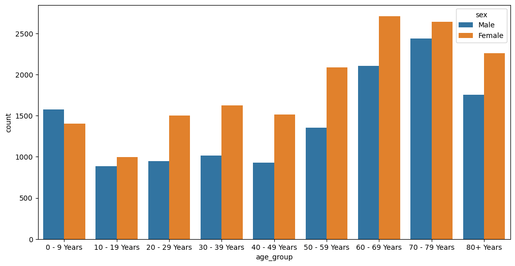

```python
# And now we create the countplot itself.
ageGroupOrder = ['0 - 9 Years', '10 - 19 Years', '20 - 29 Years', '30 - 39 Years', '40 - 49 Years', '50 - 59 Years', '60 - 69 Years', '70 - 79 Years', '80+ Years']

# Let's expand the length so the age group names doesn't interfere with others in the same space for readability.
pythPlt.figure(figsize=(12, 6))
sbn.countplot(data = cleaned_df, x = 'age_group', hue = 'sex', order = ageGroupOrder)
```

```python
# Next, we create a countplot for the death_yn column with age_group column as the hue.
# First, we get the value counts of the age_group column.
cleaned_df['age_group'].value_counts()
```

```
age_group
70 - 79 Years    5081
60 - 69 Years    4814
80+ Years        4012
50 - 59 Years    3436
0 - 9 Years      2977
30 - 39 Years    2634
20 - 29 Years    2449
40 - 49 Years    2440
10 - 19 Years    1884
Name: count, dtype: int64
```

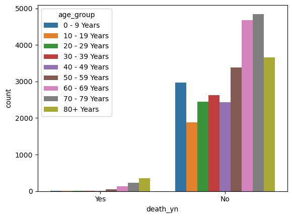

```python
# And now we create the countplot itself with the age group sorted in the legend and the order as yes first, then no.
sbn.countplot(data = cleaned_df, x = 'death_yn', hue = 'age_group', hue_order = ageGroupOrder, order = ['Yes', 'No'])
```

```python
# Next, we need to create a countplot for the medcond_yn column with age_group column as the hue.
# First, we get the value counts of the age_group column.
cleaned_df['age_group'].value_counts()
```

```
age_group
70 - 79 Years    5081
60 - 69 Years    4814
80+ Years        4012
50 - 59 Years    3436
0 - 9 Years      2977
30 - 39 Years    2634
20 - 29 Years    2449
40 - 49 Years    2440
10 - 19 Years    1884
Name: count, dtype: int64
```

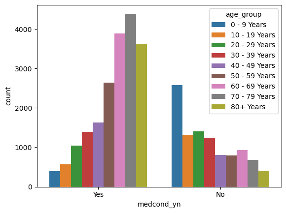

```python
# And now we create the countplot itself with the age group sorted in the legend and the order as yes first, then no.
sbn.countplot(data = cleaned_df, x = 'medcond_yn', hue = 'age_group', hue_order = ageGroupOrder, order = ['Yes', 'No'])
```

```python
# Finally, we need to encode the categorical values using the LabelEncoder() module.
# First, we import the LabelEncoder.
encdrLbLObj = LabelEncoder()
```

```python
# And here, we get the columns of the categorized dataFrame where the entries are objects.
clmnsCatgrcLLL = cleaned_df.select_dtypes(include = 'object').columns
clmnsCatgrcLLL
```

```
Index(['current_status', 'sex', 'age_group', 'Race', 'hosp_yn', 'icu_yn',
       'death_yn', 'medcond_yn'],
      dtype='object')
```

```python
# We can use a for loop to fit transform the columns in the label encoder.
for clmn in clmnsCatgrcLLL:
  cleaned_df[clmn] = encdrLbLObj.fit_transform(cleaned_df[clmn])
```

[output not shown]

```python
# The categorical values have been encoded with the LabelEncoder() module.
cleaned_df.head()
```

|  | current_status | sex | age_group | Race | hosp_yn | icu_yn | death_yn | medcond_yn |
| --- | --- | --- | --- | --- | --- | --- | --- | --- |
| 0 | 0 | 1 | 1 | 2 | 0 | 0 | 0 | 1 |
| 76 | 1 | 1 | 1 | 2 | 0 | 0 | 0 | 1 |
| 107 | 1 | 1 | 1 | 2 | 0 | 0 | 0 | 1 |
| 312 | 0 | 1 | 2 | 3 | 0 | 0 | 0 | 1 |
| 749 | 0 | 1 | 4 | 6 | 0 | 0 | 0 | 1 |

```python
# Now we are creating a heatmap of the correlation between the columns (features).
# First, we get the correlation matrix.
corrMatrix = cleaned_df.corr()
corrMatrix
```

|  | current_status | sex | age_group | Race | hosp_yn | icu_yn | death_yn | medcond_yn |
| --- | --- | --- | --- | --- | --- | --- | --- | --- |
| current_status | 1.000000 | -0.050012 | -0.075349 | 0.057073 | -0.281775 | -0.106654 | -0.077767 | -0.071449 |
| sex | -0.050012 | 1.000000 | -0.010560 | 0.014920 | 0.062060 | 0.034582 | 0.022626 | -0.012788 |
| age_group | -0.075349 | -0.010560 | 1.000000 | 0.199139 | 0.377751 | 0.133430 | 0.150858 | 0.512664 |
| Race | 0.057073 | 0.014920 | 0.199139 | 1.000000 | 0.119500 | 0.027792 | 0.038968 | 0.087861 |
| hosp_yn | -0.281775 | 0.062060 | 0.377751 | 0.119500 | 1.000000 | 0.369767 | 0.296977 | 0.268869 |
| icu_yn | -0.106654 | 0.034582 | 0.133430 | 0.027792 | 0.369767 | 1.000000 | 0.446016 | 0.112231 |
| death_yn | -0.077767 | 0.022626 | 0.150858 | 0.038968 | 0.296977 | 0.446016 | 1.000000 | 0.111656 |
| medcond_yn | -0.071449 | -0.012788 | 0.512664 | 0.087861 | 0.268869 | 0.112231 | 0.111656 | 1.000000 |

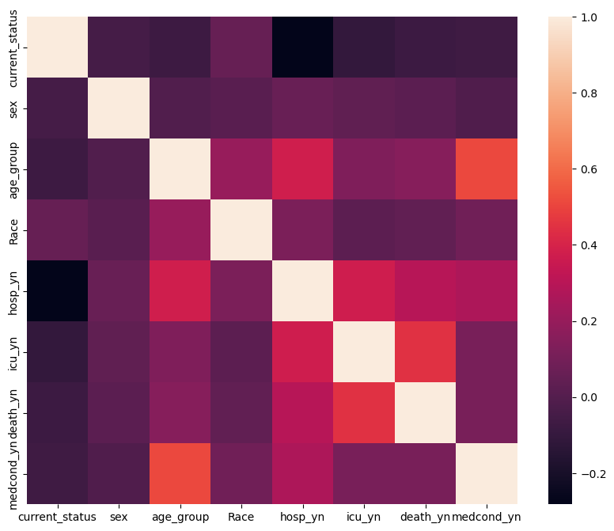

```python
# And now we plot the heatmap using the correlated matrix and the annotations present.
pythPlt.figure(figsize = (10, 8))
sbn.heatmap(corrMatrix)
```

# **Part 3**

### Logistic Regression

```python
x = cleaned_df.drop(['death_yn'],axis=1)
y = cleaned_df['death_yn']

x_train, x_test, y_train, y_test = train_test_split(x, y, test_size=0.2, random_state=42)

scaler = StandardScaler()
x_train = scaler.fit_transform(x_train)
x_test = scaler.transform(x_test)

log_mod = LogisticRegression(random_state=42)
```

```python
log_mod.fit(x_train,y_train)
```

```
LogisticRegression(random_state=42)
```

```python
log_mod.coef_
```

```
array([[ 0.19800422, -0.0197003 ,  1.01106502, -0.04031348,  1.21760632,
         0.48676411,  0.68686399]])
```

```python
coeff_cleaned_df = pnds.DataFrame(log_mod.coef_[0],x.columns,columns=['Coefficient'])
coeff_cleaned_df
```

|  | Coefficient |
| --- | --- |
| current_status | 0.198004 |
| sex | -0.019700 |
| age_group | 1.011065 |
| Race | -0.040313 |
| hosp_yn | 1.217606 |
| icu_yn | 0.486764 |
| medcond_yn | 0.686864 |

```python
y_pred = log_mod.predict(x_test)

accuracy_score(y_test,y_pred)
```

```
0.9752774974772956
```

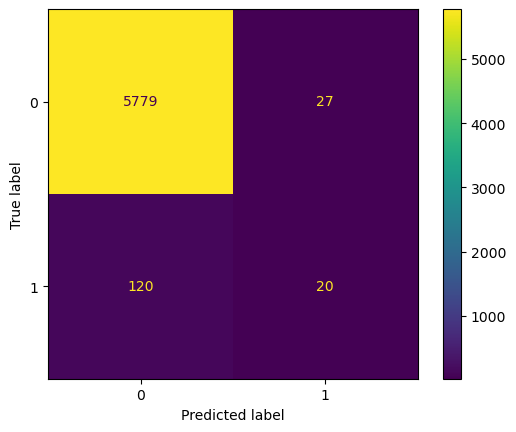

```python
cm = confusion_matrix(y_test,y_pred,labels=log_mod.classes_)

display = ConfusionMatrixDisplay(confusion_matrix=cm,display_labels=log_mod.classes_)
display.plot()
pythPlt.show()
```

```python
print(classification_report(y_test,y_pred))
```

```
              precision    recall  f1-score   support

           0       0.98      1.00      0.99      5806
           1       0.43      0.14      0.21       140

    accuracy                           0.98      5946
   macro avg       0.70      0.57      0.60      5946
weighted avg       0.97      0.98      0.97      5946
```

```python
x.iloc[10]
```

```
current_status    0
sex               1
age_group         6
Race              6
hosp_yn           0
icu_yn            0
medcond_yn        0
Name: 1914, dtype: int64
```

```python
y.iloc[10]
```

```
0
```

```python
log_mod.predict_proba(x.iloc[10].values.reshape(1, -1))
```

```
array([[0.59568146, 0.40431854]])
```

### Decision Tree

```python
x = cleaned_df.drop(['death_yn'],axis=1)
y = cleaned_df['death_yn']

x_train, x_test, y_train, y_test = train_test_split(x, y, test_size=0.2, random_state=42)

scaler = StandardScaler()
x_train = scaler.fit_transform(x_train)
x_test = scaler.transform(x_test)

mod = DecisionTreeClassifier(random_state=42)
```

```python
mod.fit(x_train,y_train)
```

```
DecisionTreeClassifier(random_state=42)
```

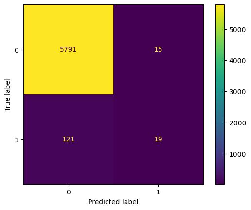

```python
y_pred = mod.predict(x_test)
cm = confusion_matrix(y_test,y_pred)
display = ConfusionMatrixDisplay(confusion_matrix=cm)
display.plot()
pythPlt.show()
```

```python
print(classification_report(y_test,y_pred))
```

```
              precision    recall  f1-score   support

           0       0.98      1.00      0.99      5806
           1       0.56      0.14      0.22       140

    accuracy                           0.98      5946
   macro avg       0.77      0.57      0.60      5946
weighted avg       0.97      0.98      0.97      5946
```

```python
mod.feature_importances_
```

```
array([0.01917327, 0.02787485, 0.12305869, 0.06451565, 0.07066947,
       0.66001024, 0.03469783])
```

```python
pnds.DataFrame(index=x.columns,data=mod.feature_importances_,columns=['Feature Importance'])
```

|  | Feature Importance |
| --- | --- |
| current_status | 0.019173 |
| sex | 0.027875 |
| age_group | 0.123059 |
| Race | 0.064516 |
| hosp_yn | 0.070669 |
| icu_yn | 0.660010 |
| medcond_yn | 0.034698 |

### SVM

```python
x = cleaned_df.drop(['death_yn'],axis=1)
y = cleaned_df['death_yn']

x_train, x_test, y_train, y_test = train_test_split(x, y, test_size=0.2, random_state=42)

scaler = StandardScaler()
x_train = scaler.fit_transform(x_train)
x_test = scaler.transform(x_test)

svm = SVC(random_state=42)
```

```python
svm.fit(x_train, y_train)
```

```
SVC(random_state=42)
```

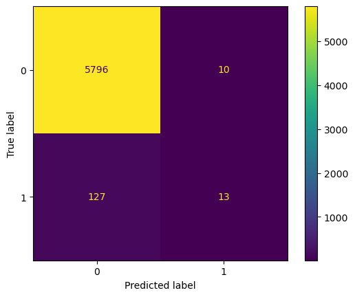

```python
y_pred = svm.predict(x_test)
cm = confusion_matrix(y_test,y_pred)
display = ConfusionMatrixDisplay(confusion_matrix=cm)
display.plot()
pythPlt.show()
```

```python
print(classification_report(y_test,y_pred))
```

```
              precision    recall  f1-score   support

           0       0.98      1.00      0.99      5806
           1       0.57      0.09      0.16       140

    accuracy                           0.98      5946
   macro avg       0.77      0.55      0.57      5946
weighted avg       0.97      0.98      0.97      5946
```

# logistic regression using specified parameters

```python
x = cleaned_df.drop(['death_yn'],axis=1)
y = cleaned_df['death_yn']

x_train, x_test, y_train, y_test = train_test_split(x, y, test_size=0.2, random_state=42)

scaler = StandardScaler()
x_train = scaler.fit_transform(x_train)
x_test = scaler.transform(x_test)

logistic_parameters = [
    {'penalty': ['l1'], 'solver': ['liblinear', 'saga'], 'C': pyNum.logspace(0, 4, 10)},
    {'penalty': ['l2'], 'solver': ['liblinear', 'sag', 'saga', 'lbfgs'], 'C': pyNum.logspace(0, 4, 10)}]

lr = LogisticRegression(random_state=42)
grid_lr = GridSearchCV(estimator=lr, param_grid=logistic_parameters, cv=10, n_jobs=-1)
```

```python
grid_lr.fit(x_train, y_train)
```

```
GridSearchCV(cv=10, estimator=LogisticRegression(random_state=42), n_jobs=-1,
             param_grid=[{'C': array([1.00000000e+00, 2.78255940e+00, 7.74263683e+00, 2.15443469e+01,
       5.99484250e+01, 1.66810054e+02, 4.64158883e+02, 1.29154967e+03,
       3.59381366e+03, 1.00000000e+04]),
                          'penalty': ['l1'], 'solver': ['liblinear', 'saga']},
                         {'C': array([1.00000000e+00, 2.78255940e+00, 7.74263683e+00, 2.15443469e+01,
       5.99484250e+01, 1.66810054e+02, 4.64158883e+02, 1.29154967e+03,
       3.59381366e+03, 1.00000000e+04]),
                          'penalty': ['l2'],
                          'solver': ['liblinear', 'sag', 'saga', 'lbfgs']}])
```

```python
grid_lr.best_params_
```

```
{'C': 1.0, 'penalty': 'l1', 'solver': 'liblinear'}
```

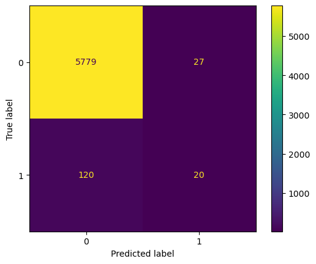

```python
y_pred = grid_lr.predict(x_test)
cm = confusion_matrix(y_test,y_pred)

display = ConfusionMatrixDisplay(confusion_matrix=cm)
display.plot()
pythPlt.show()
```

```python
print(classification_report(y_test,y_pred))
```

```
              precision    recall  f1-score   support

           0       0.98      1.00      0.99      5806
           1       0.43      0.14      0.21       140

    accuracy                           0.98      5946
   macro avg       0.70      0.57      0.60      5946
weighted avg       0.97      0.98      0.97      5946
```

# SVM using specified parameters

```python
params_svc= {'C': [0.1, 1, 10, 100],
              'gamma': [1, 0.1, 0.01, 0.001],
              'kernel': ['rbf','linear']}

svm = SVC(random_state=42, max_iter=5000) #Limiting iterations just for gridsearch

grid_svm = GridSearchCV(estimator=svm, param_grid=params_svc, cv=10, n_jobs=-1)
```

```python
grid_svm.fit(x_train, y_train)
```

[output not shown]

[output cut: 199 more lines]

[output not shown]

```
GridSearchCV(cv=10, estimator=SVC(max_iter=5000, random_state=42), n_jobs=-1,
             param_grid={'C': [0.1, 1, 10, 100], 'gamma': [1, 0.1, 0.01, 0.001],
                         'kernel': ['rbf', 'linear']})
```

```python
grid_svm.best_params_
```

```
{'C': 100, 'gamma': 1, 'kernel': 'rbf'}
```

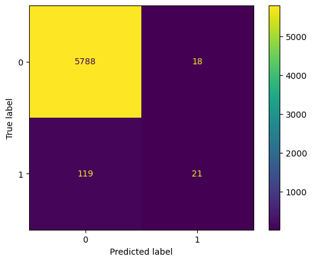

```python
svm = SVC(**grid_svm.best_params_, random_state=42) # Now that best_params are found we can run without limiting iterations
svm.fit(x_train, y_train)

y_pred = svm.predict(x_test)
cm = confusion_matrix(y_test,y_pred)

display = ConfusionMatrixDisplay(confusion_matrix=cm)
display.plot()
pythPlt.show()
```

```python
print(classification_report(y_test,y_pred))
```

```
              precision    recall  f1-score   support

           0       0.98      1.00      0.99      5806
           1       0.54      0.15      0.23       140

    accuracy                           0.98      5946
   macro avg       0.76      0.57      0.61      5946
weighted avg       0.97      0.98      0.97      5946
```

# Decision Tree Classifier with specified parameters

```python
tree_parameters = {'criterion': ['gini', 'entropy', 'log_loss'], 'max_depth': [1, 2, 3, 5, 10, 50, 100]}

dt = DecisionTreeClassifier(random_state=42)

grid_dt = GridSearchCV(estimator=dt, param_grid=tree_parameters, cv=10, n_jobs=-1)
```

```python
grid_dt.fit(x_train, y_train)
```

```
GridSearchCV(cv=10, estimator=DecisionTreeClassifier(random_state=42),
             n_jobs=-1,
             param_grid={'criterion': ['gini', 'entropy', 'log_loss'],
                         'max_depth': [1, 2, 3, 5, 10, 50, 100]})
```

```python
grid_dt.best_params_
```

```
{'criterion': 'gini', 'max_depth': 50}
```

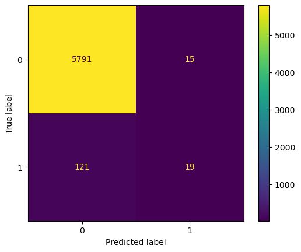

```python
y_pred = grid_dt.predict(x_test)
cm = confusion_matrix(y_test,y_pred)

display = ConfusionMatrixDisplay(confusion_matrix=cm)
display.plot()
pythPlt.show()
```

```python
print(classification_report(y_test,y_pred))
```

```
              precision    recall  f1-score   support

           0       0.98      1.00      0.99      5806
           1       0.56      0.14      0.22       140

    accuracy                           0.98      5946
   macro avg       0.77      0.57      0.60      5946
weighted avg       0.97      0.98      0.97      5946
```

# Use the weighted Average of Precision, Recall and F1-Score to compare the performance of the model.

## Decission Tree Classifier

For Decission Tree Classifier, the original model had weighted averages of, Precision - 0.97 Recall - 0.98 F-1 - 0.97

where the updated model has Precision - 0.97 Recall - 0.98 F-1 - 0.97 As can be seen by comparing the values from both there was no change between the two models.

## Logistic Regression

For Logistic Regression, the original model had weighted averages of, Precision - 0.97 Recall - 0.98 F-1 - 0.97

where the updated model has Precision - 0.97 Recall - 0.98 F-1 - 0.97 As can be seen by comparing the values from both there was no change between the two models.

## SVM

For SVM, the original model had weighted averages of, Precision - 0.97 Recall - 0.98 F-1 - 0.97

where the updated model has Precision - 0.97 Recall - 0.98 F-1 - 0.97 As can be seen by comparing the values from both there was no change between the two models.

# Compare the performance of the default models with the optimized models.